# Stochastic approximation

In this notebook, we explore stochastic approximation and Robbins-Monro algorithm to find the roots or extrema of a function $f(\theta) = \mathbb E_{\xi} [F(\theta,\xi)]$. Instead of evaluating it directly, we randomly draw some values $F(\theta,\xi)$ to approximate the properties of $f$.

A practical example is the case of a function whose values cannot be computed exactly because of a corrupting noise.

```python
import numpy as np
import matplotlib.pyplot as plt
%matplotlib inline
```

# Noisy function

In this first example, we consider a function $f$, unknown in reality. Whenever this function is evaluated, a noise alters the real value. How is it possible to determine the roots of $f$ ?

```python
sigma_noise = 100

def f(x):
    return -10*(x-10)*(x+10)

def noisy_f(x):
    return np.random.normal(loc=f(x), scale=sigma_noise)
```

```python
X = np.linspace(-5,20,1000)
```

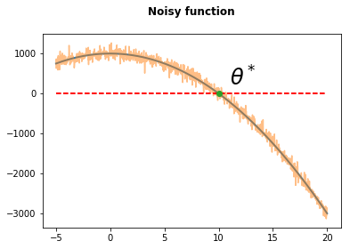

```python
y1 = f(X)
y2 = np.zeros(len(X))
for i in range(len(X)):
    y2[i] = noisy_f(X[i])
_= plt.plot(X, y1, linewidth=2.0)
_= plt.plot(X, y2, alpha=0.5)
_= plt.plot(X, [0]*len(X), 'r--', linewidth=2.0)
_= plt.plot(10, 0, marker='o')
_= plt.text(11, 200, r'$\theta^*$', fontsize=24, fontweight='bold')
_= plt.title('Noisy function', y=1.07, fontweight='bold')
```

## Root finding by estimating $f$ at each point (Monte-Carlo)

A first method to find the roots of $f$ is a simplification of Newton's method : let $\epsilon>0$ , the root $\theta^*$ is estimated recursively by $\theta_{n+1}=\theta_n+\epsilon \cdot \bar f(\theta_n)$, assuming f is non-increasing on a neighborhood of $\theta^*$. $\bar f(\theta_n)$ is an estimation of $f(\theta_n)$ computed in the following example by evaluating $N$ times $f$ in $\theta_n$. We use here the Law of Large Numbers, which states that the empirical mean of i.i.d variables converges to the expected value of the variable with probability one.

```python
def naive_opt(theta_0=0, N=100, epsilon=0.01, n_step=100):
    theta_list = [theta_0]*n_step
    for i in range(n_step-1):
        f_est = 0
        for j in range(N):
            f_est = f_est + 1/(j + 1)*(noisy_f(theta_list[i]) - f_est)
        theta_list[i+1] = theta_list[i] + epsilon*f_est
    return theta_list
```

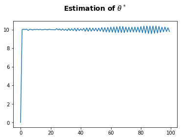

```python
theta_list = naive_opt(N=1000)
_= plt.plot(theta_list)
_= plt.title('Estimation of '+ r'$\theta^*$', y=1.07, fontsize=14, fontweight='bold')
```

With this method, the root is corectly estimated. However, from an estimation of $\theta$, a high number of random draws is necessary to obtain the next estimation. As a consequence, this algorithm is too slow.

## Robbins-Monro algorithm

Let's assume now that we have a function $f(\theta)$ and a constant $\alpha$ so that the equation $f(\theta)=\alpha$ has a unique solution $\theta^*$. Let's assume also that $f$ is not directly observable, but that it is possible to get some values of the random variable $X(\theta)$ so that $\mathbb E[X(\theta)]=f(\theta)$. Robbins-Monro algorithm generates the following recursive sequence: $\theta_{n+1}=\theta_n-a_n\cdot(X(\theta_n)-\alpha)$

where $(a_i)$ is a positive sequence. Robbins and Monro proved the convergence of $(\theta_n)$ in $L^2$ to $\theta^*$, and Blum proved later that it converged with probability one, by forcing:

- $X(\theta)$ is uniformly bounded
- $f(\theta)$ is non-decreasing
- $f'(\theta^*)$ exists and is non-negative
- $ \sum\limits_{n=0}^{\infty}a_n = \infty$ and $\sum\limits_{n=0}^{\infty}a^2_n < \infty$

The choice of the sequence $a_n=\frac{a}{n}$ with $a>0$ is suggested by Robbins et Monro (and we easily verify that this sequence satisfies the conditions of the theorem).

```python
def rm_opt(theta_0=0, f_eps=lambda i: 1/(i+100), n_step=100):
    theta_list = [theta_0]*n_step
    for i in range(n_step-1):
        epsilon = f_eps(i)
        theta_list[i+1] = theta_list[i] + epsilon*noisy_f(theta_list[i])
    return theta_list
```

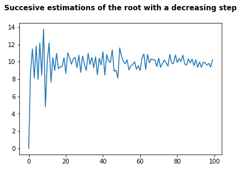

```python
theta_list = rm_opt()
_= plt.plot(theta_list)
_= plt.title('Succesive estimations of the root with a decreasing step',y=1.07,fontweight='bold')
```

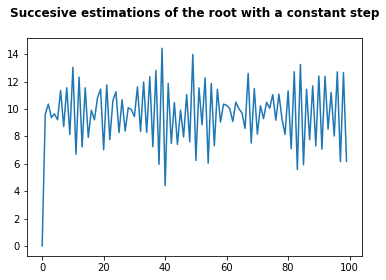

```python
theta_list = rm_opt(theta_0=0, f_eps=lambda i: 0.01)
_= plt.plot(theta_list)
_= plt.title('Succesive estimations of the root with a constant step',y=1.07,fontweight='bold')
```

The second graph shows more noise than the first one: because of the constant step, each measure contributes as much as the current estimation of $\theta^*$. As a consequence, the noise is not "damped".

## Recursive least squares

Let us consider another case of Robbins-Monro algorithm, the estimation of the expected value of a random variable by the method of least squares. The estimation of the expected value $\bar \theta$ is $\theta_n =\frac{1}{n}\sum\limits_{i=1}^{N}\xi_i$, where the $\xi_i$ are the observations. In a recursive way, this can be written:

$\theta_{n+1} = \theta_n + \epsilon_n[\xi_{n+1}-\theta_n]$

where $\theta_0=0$ and $\epsilon_n=1/(n+1)$

Consequently, a decreasing step $\epsilon_n=1/(n+1)$ allows us to build an estimator equivalent to the direct mean of the observations. This example clearly shows how Robbins-Monro algorithm rejoins the classical least squares estimation.

The recursive form of the method of least squares also fosters intuition: the estimator only changes by a factor $\epsilon_n[\xi_{n+1}-\theta_n]$, that is the product of a «trust coefficient» $\epsilon_n$ and an «estimation error» $\xi_{n+1}-\theta_n$.

```python
n = 1500
mean = 100
theta = [0]*(n+1)
for i in range(n):
    e = 1/(i+1)
    ksi = np.random.normal(loc=mean, scale=100.0)
    theta[i+1] = theta[i] + e*(ksi - theta[i])
```

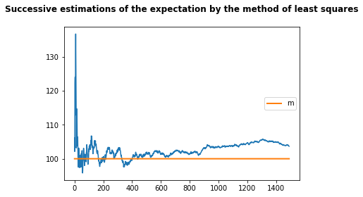

```python
_= plt.plot(theta[10:])
mean_plot = plt.plot([mean]*len(theta[10:]), linewidth=2.0)
_= plt.title('Successive estimations of the expectation by the method of least squares',y=1.07,fontweight='bold')
_= plt.legend(mean_plot, 'm', loc=7)
```

# Stochastic gradient descent: an application of Robbins-Monro algorithm

In order to minimize an objective function $J$, the parameters $W$ of a model are generally adjusted in the following way, by using gradient descent:

$W = W - \epsilon \cdot \nabla_W J(W)$

For example, in the case of the empirical risk, $J(W) = \frac{1}{N}\sum\limits_{i=1}^{N}f_i(W)$, the gradient is computed on each point of the training set before $W$ is updated and it requires a complete pass through the training set for each update. On large datasets, the minimization of the objective function can become extremely slow and this algorithm does not allow to update the parameters online. Moreover, this algorithm poorly handles redundant data. To be convinced of this, let's assume that we add to the training set a copy of itself. The complete pass through the second half of the training set does not have any effect on the update of $W$.

Stochastic gradient descent, on the contrary, updates the parameters $W$ for each example of the training set. For each example $(x^{(i)},y^{(i)})$, $W$ is updated in the following way: $W = W - \epsilon \cdot \nabla_W f_i(W)$

By considering every $\nabla_W f_i(W)$ as an approximation of $\nabla_W J(W)$, Robbins-Monro algorithm allows us to find $W^*$ if the sequence $\epsilon$ verifies the hypotheses of the theorem. The difference between classical gradient descent and stochastic gradient descent is the same as the difference between root finding by estimation of $f$ on each point encountered and root finding with Robbins-Monro algorithm.

In practice, it is more common to compute the gradient $\nabla_W J(W)$ on a batch.

# Animal learning model

In this last example, we consider the learning model of an animal (a lion for instance), trying to maximize its food consumption rate by unit of time. We propose to show an application of Robbins-Monro algorithm convergence on this example.

The lion lives in a limited territory and can chase its preys in a limited area. Zebras appear at random times, their weight is also random and directly linked to their nutritional value. If a zebra appears while the lion is ready to chase (i.e., the lion is in its territory), then the lion can choose to chase its prey, with the (implicit) intention to maximize its quantity of food obtained by unit of time, or to stay in its territory. We suppose that when the lion is chasing, no more zebra appears.

Let us define the variables of the problem: at time $0$, the lion is in its territory. Let $\tau_1$ be the time to which the first zebra appears. If the lion decides to go chasing, let $r_1$ be the time taken by the lion to chase and reach back its territory. More generally: $\tau_n$ is the elapsed time since zebra $n-1$ appeared until zebra $n$ appearance if the lion was not chasing, or since the return of chasing of zebra $n-1$ if chased. $r_n$ is the time taken to chase zebra $n$ and reach back the territory, $w_n$ is zebra $n$ weight, $J_n$ equals $1$ if zebra $n$ has been caught, $0$ else, $I_n$ equals $1$ if zebra $n$ has been chased, $0$ else, and $T_n$ is the elapsed time at the moment of decision $n-1$.

The lion knows the tuple $(w_n,r_n)$ at the time the zebra appears. Let $W_n = \sum\limits_{i=1}^{n-1}w_i\cdot I_i\cdot J_i$ be the total weight of zebra consumed until time $T_n$. Finally, let $\theta_n = T_n/W_n$ be the inverse of the consumption rate by unit of time.

We suppose that the random variables $(w_n,\tau_n,r_n)$ do not depend on $n$ and are identically distributed, with $w_n > 0$ and $\tau_n > 0$ for all $n$. We suppose also that $\mathbb E(J_n|r_n,w_n) = p(r_n,w_n)$, with $p$ a continuous function and $p(r_n,w_n)$ > $0$ for all $n$, this function $p$ being known by the lion.

The random variables distributions of $w, r, \tau$ and $p(w,r)$ are given.

## Naive strategy :

First, we propose to implement the following hunting strategy: the lion goes chasing whenever a zebra appears. The random distributions $w_n$, $r_n$, $\tau_n$ and $p(w_n,r_n)$ are given.

```python
n = 100000 # number of iterations
W = 0 # Weight of zebra consumed by the lion since the beginning
T = 0 # Elapsed time

theta_list = [0]*(n+1) # Inverse of the consumntion rate by unit of time
theta_var = [0]*n # Variation of theta from an iteration to the next one
theta_list[0] = 1 # Threshold initialization

I_list = [0]*n # Zebra i is chased or not
J_list = [0]*n # Zebra i is cought or not
p_catch_list = [0]*n

for i in range(n):
    tau = np.random.normal(loc=12, scale=2.0)
    w = max(10,min(100, np.random.normal(loc=50, scale=15)))
    r = max(10,min(100, np.random.normal(loc=50, scale=15)))
    I_list[i] = 0
    p_catch_list[i] = (100 - np.abs(50 - r)) * w /(100*100)

    if 1:
        I_list[i] = 1 # Zebra i is hunted
        J_list[i] = np.random.binomial(1, p_catch_list[i])

    # Update of W, T, theta and theta_var
    W = W + w*I_list[i]*J_list[i]
    T = T + tau + r*I_list[i]
    if W != 0:
        theta_list[i+1] = T/W
    else:
        theta_list[i+1] = theta_list[i] + 1 # Initial threshold increased if too small
    theta_var[i] = theta_list[i+1] - theta_list[i]
```

```
The lion goes chasing 100000 times over 100000
The lion catches its prey 44228 times over 100000 attempts
The lion consumntion rate is 0.38858495715034574
```

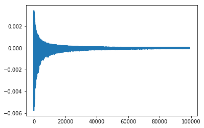

```python
_= plt.plot(theta_var[1000:])
print('The lion goes chasing {} times over {}'.format(sum(I_list), n))
print('The lion catches its prey {} times over {} attempts'.format(sum(J_list), sum(I_list)))
print('The lion consumntion rate is {}'.format(W/T))
```

## Stochastic approximation strategy :

Let us now consider the following strategy:

Let $\bar{\theta}$ be $\lim(\inf_n(\mathbb E(T_n/W_n))$. The optimal strategy on the long run is given by the following decision rule:

___"Chasing if $r_n \leq \bar{\theta} \cdot w_n \cdot p(r_n,w_n)$"___

I.e., chasing only if the ratio between chasing duration and the expected food reward is below $\bar{\theta}$.

The learning algorithm will generate a sequence $\theta_n$ converging to $\bar{\theta}$ with probability $1$. Indeed, the following decision rule asymptotically approximates the optimal strategy:

___"Chasing if $r_n \leq \theta \cdot w_n \cdot p(r_n,w_n)$"___

One can prove that $\theta_n$ is updated the following way:

$ \theta_{n+1} = \theta_{n} + \epsilon_n \cdot g(\theta_{n}) $

where $\epsilon_n = 1/W_n$. [1] proves that $\epsilon_n$ goes to $0$ with probabilty $1$, and $g$ is Lipschitz continuous, positive for $\theta = 0 $, approximatively proportionnal to $-\theta$ for sufficiently big $\theta$, having a unique root $\bar{\theta}$. We can thus apply Robbins Monro theorem and conclude that $\theta$ converges to a minimum $\bar{\theta}$ which maximises the lion consumption rate by unit of time.

```python
n = 100000 # number of iterations
W = 0 # Weight of zebra consumed by the lion since the beginning
T = 0 # Elapsed time

theta_list = [0]*(n+1) # Inverse of the consumntion rate by unit of time
theta_var = [0]*n # Variation of theta from an iteration to the next one
theta_list[0] = 1 # # Threshold initialization

I_list = [0]*n # Zebra i is chased or not
J_list = [0]*n # Zebra i is caught or not

p_catch_list = [0]*n

for i in range(n):
    tau = np.random.normal(loc=12, scale=2.0)
    w = max(10, min(100, np.random.normal(loc=50, scale=15)))
    r = max(10, min(100, np.random.normal(loc=50, scale=15)))

    I_list[i] = 0
    p_catch_list[i] = (100 - np.abs(50 - r)) * w / (100*100)

    if r <= theta_list[i] * w * p_catch_list[i]: # Zebra i chasing decision
        I_list[i] = 1
        J_list[i] = np.random.binomial(1, p_catch_list[i]) # Bernoulli of parameter p_catch_list[i]

    # Update of W, T, theta and theta_var
    W = W + w*I_list[i]*J_list[i]
    T = T + tau + r*I_list[i]
    if W != 0:
        theta_list[i+1] = T/W
    else:
        theta_list[i+1] = theta_list[i] + 1 # Initial threshold increased if too small
    theta_var[i] = theta_list[i+1] - theta_list[i]
```

```
The lion goes chasing 45442 times over 100000
The lion catches its prey 24730 times over 45442 attempts
The lion consumntion rate is 0.4904014673859078
```

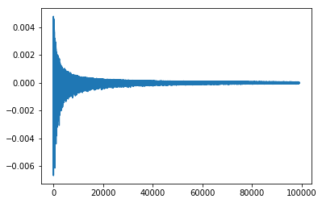

```python
_= plt.plot(theta_var[1000:])
print('The lion goes chasing {} times over {}'.format(sum(I_list), n))
print('The lion catches its prey {} times over {} attempts'.format(sum(J_list), sum(I_list)))
print('The lion consumntion rate is {}'.format(W/T))
```

**References:**

- [1] Kushner, H. J., Yin, G., & Kushner, H. J. (2003). Stochastic approximation and recursive algorithms and applications. New York: Springer.
- [2] http://sebastianruder.com/optimizing-gradient-descent/index.html
- [3] https://en.wikipedia.org/wiki/Stochastic_approximation